# Benchmarks and supplementary diagnostics

This notebook reproduces the benchmark plots and supplementary diagnostics that rely primarily on cached outputs bundled with the submission.

# Pruning sensitivity: runtime vs accuracy

The next chunks reproduce Figure 7 in Section 4.2 of the main text.

In the next two chunks we study the effect of **pruning** in the dual particle filter by running the algorithm under different pruning levels and comparing both execution time and accuracy as the pruning threshold changes.

```r
my_labels <- c("    1 node", "  10 nodes", "100 nodes", "  90% mass", "  95% mass", "100% mass")

my_times <- read.csv(cached_results_path("my_times.csv"))
my_times$Pruning <- factor(my_times$Pruning, levels = my_labels, ordered = TRUE)

my_scores <- read.csv(cached_results_path("my_scores.csv"))
my_scores$Pruning <- factor(my_scores$Pruning, levels = my_labels, ordered = TRUE)
```

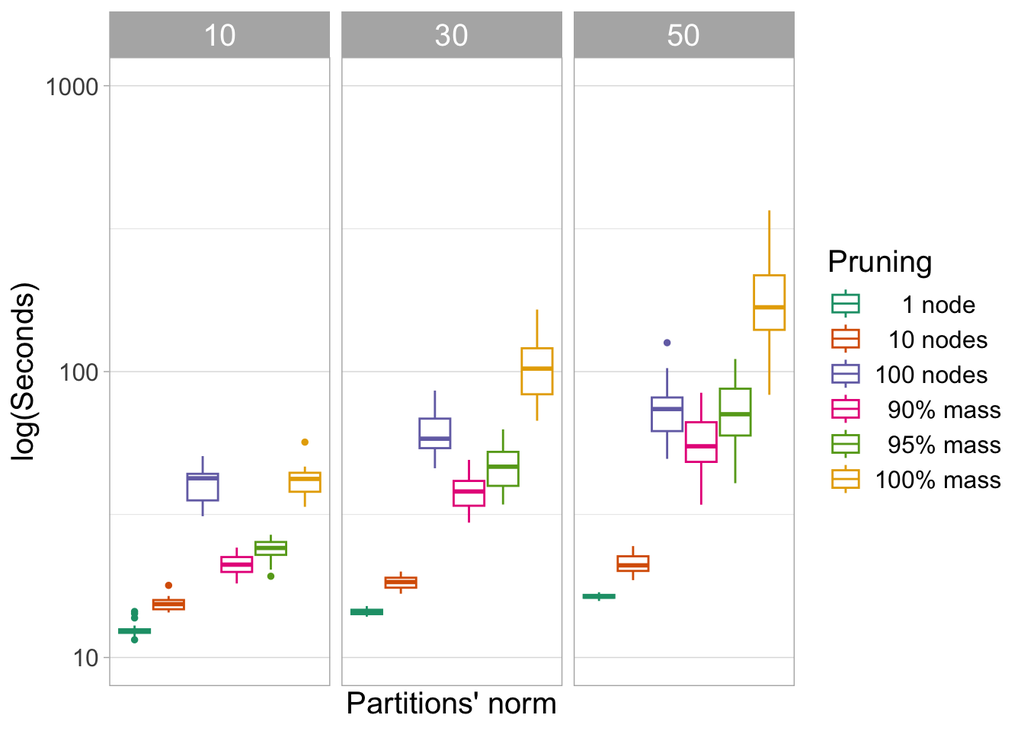

```r
my_plot_time <-
  ggplot(data = my_times) +
  geom_boxplot(aes(y = Time, color = Pruning), size = .5, show.legend = TRUE, outlier.size = 1) +
  facet_grid(. ~ factor(Observations)) +
  scale_y_continuous(transform = "log10", limits = c(10, 1000)) +
  scale_x_continuous(breaks = NULL) +
  scale_color_brewer(palette = "Dark2") +
  theme_light() +
  theme(strip.text = element_text(size = 15), text = element_text(size = 15)) +
  labs(y = "log(Seconds)", x = "Partitions' norm")

my_plot_scores <-
  ggplot(data = my_scores) +
  geom_boxplot(aes(y = Score, color = Pruning), lwd = .5, show.legend = TRUE, outlier.size = 1) +
  facet_grid(. ~ factor(Observations)) +
  scale_color_brewer(palette = "Dark2") +
  scale_x_continuous(breaks = NULL) +
  theme_light() +
  theme(strip.text = element_text(size = 15), text = element_text(size = 15)) +
  ylim(0, max(my_scores$Score)) +
  labs(y = "Score", x = "Partitions' norm")

my_plot_time
```

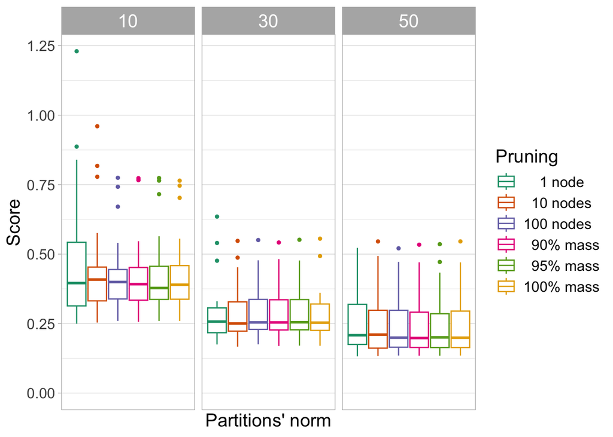

```r
my_plot_scores
```

# Comparing filtering and smoothing methods

The next chunks reproduce Figure 9 in Section 4.4 of the main text.

In the next chunks we compare the **accuracy** of the different filtering and smoothing approaches considered in the paper. These comparisons rely on extensive simulation runs and are therefore computationally expensive.

To reproduce the corresponding figure in the manuscript without re-running the full simulation study, we recommend importing the precomputed simulation outputs and directly printing the results.

```r
my_data3 <- read.csv(cached_results_path("my_data3.csv"))
```

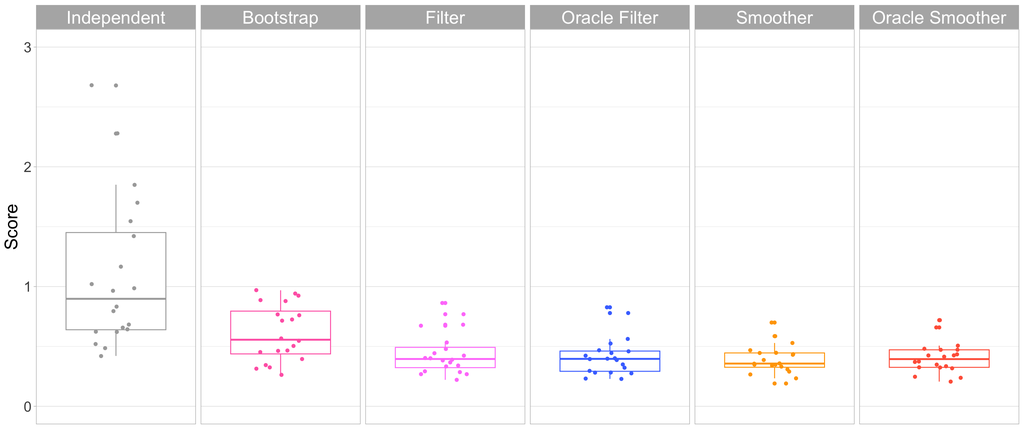

```r
my_plot3 <-
  ggplot(data = my_data3, aes(y = Data, x = "", color = factor(Type))) +
  geom_boxplot(outliers = TRUE, show.legend = FALSE, outlier.size = 1.5, coef = 1) +
  geom_jitter(width = 0.2, size = 1.5, show.legend = FALSE) +
  scale_x_discrete(breaks = NULL) +
  ylim(0, 3) +
  facet_grid(. ~ factor(Type, levels = c("Independent", "Bootstrap", "Filter", "Oracle Filter", "Smoother", "Oracle Smoother"))) +
  scale_colour_manual(values = c("hotpink", "orchid1", "darkgray", "royalblue1", "tomato", "orange")) +
  theme_light() +
  theme(strip.text = element_text(size = 20), text = element_text(size = 20)) +
  labs(y = "Score", x = "")

my_plot3
```

# Proportion of filtering mixture components

The following chunks return Figure SM.2 in Section SM.4.2 of the supplement.

Here we investigate how the mixing measure concentrates on the coagulations indexing the (dual) filtering distribution – a diagnostic on the concentration of the filtering mixture over the active coagulations The figures show that most of the mass is concentrated on a small subset of the coagulation, thereby justifying the use of the pruning strategy.

```r
size_top_update <- read.csv(cached_results_path("size_top_update.csv"))
size_top_update$time <- as.factor(size_top_update$time)

top_update_relative <- read.csv(cached_results_path("top_update_relative.csv"))
top_update_relative$time <- as.factor(top_update_relative$time)

size_top_propagation <- read.csv(cached_results_path("size_top_propagation.csv"))
size_top_propagation$time <- as.factor(size_top_propagation$time)

top_propagation_relative <- read.csv(cached_results_path("top_propagation_relative.csv"))
top_propagation_relative$time <- as.factor(top_propagation_relative$time)
```

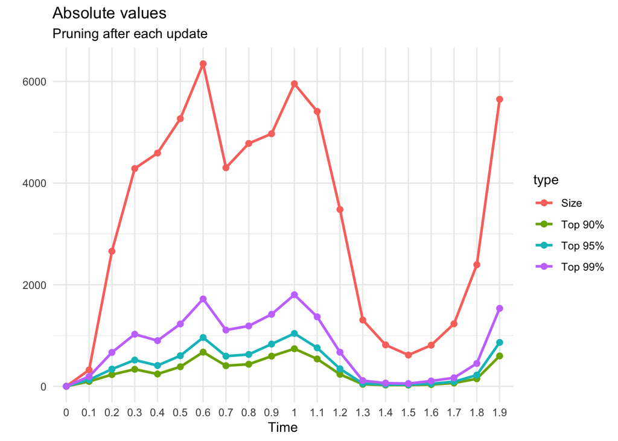

```r
plot_update_size <-
  ggplot(size_top_update, aes(x = time, y = data, colour = type, group = type)) +
  geom_line(linewidth = 1) +
  geom_point(size = 2) +
  theme_minimal() +
  labs(x = "Time", y = "", title = "Absolute values", subtitle = "Pruning after each update")

plot_update_top <-
  ggplot(top_update_relative, aes(x = time, y = data, colour = type, group = type)) +
  geom_line(linewidth = 1) +
  geom_point(size = 2) +
  theme_minimal() +
  labs(x = "Time", y = "", colour = "", title = "Relative values", subtitle = "Pruning after each update")

plot_prop_size <-
  ggplot(size_top_propagation, aes(x = time, y = data, colour = type, group = type)) +
  geom_line(linewidth = 1) +
  geom_point(size = 2) +
  theme_minimal() +
  labs(x = "Time", y = "", title = "Absolute values", subtitle = "Pruning after each propagation")

plot_prop_top <-
  ggplot(top_propagation_relative, aes(x = time, y = data, colour = type, group = type)) +
  geom_line(linewidth = 1) +
  geom_point(size = 2) +
  theme_minimal() +
  labs(x = "Time", y = "", colour = "", title = "Relative values", subtitle = "Pruning after each propagation")

plot_update_size
```

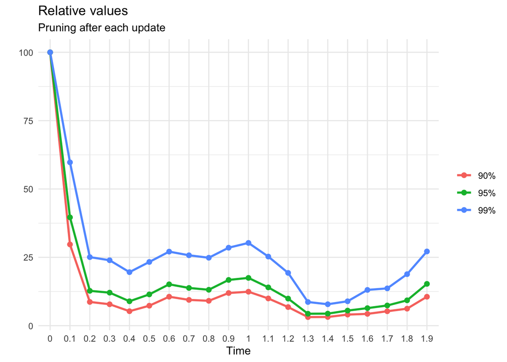

```r
plot_update_top
```

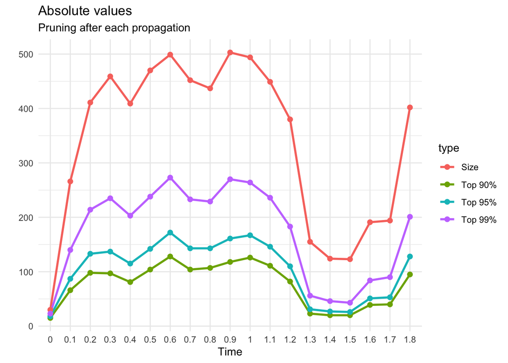

```r
plot_prop_size
```

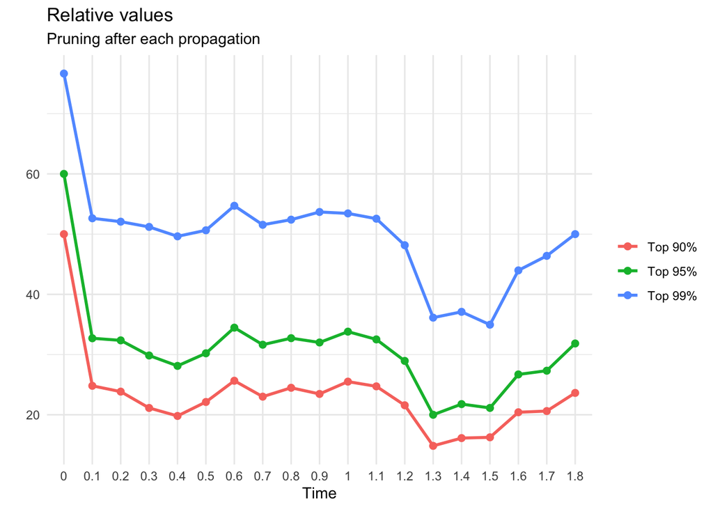

```r
plot_prop_top
```